# Using the whalestrike package

Dan Kelley

2018-08-23

**Abstract.** This vignette explains the basics of using the whalestrike package to simulate the collision of a ship with a whale.

# 1 Introduction

This package solves Newton’s second law for a simple model of a ship colliding with a whale. This is a stripped-down model that does not attempt to simulate the biomechanical interactions that can be simulated in finite-element treatments such as that of Raymond (2007). The goal is to establish a convenient framework for rapid computation of impacts in a wide variety of conditions. The model runs quickly enough to keep up with mouse movements to select conditions, in a companion R shiny app. That app lets the user see the effects of changing contact area, ship speed, etc., as a way to build intuition for scenarios ranging from collision with a slow-moving fishing boat to collision with a thin dagger-board of a much swifter racing sailboat. Another advantage of the simple formulation is that it makes it easy to modify various dynamical and biomechanical parameters, to add new forces, and to explore a range of criteria for whale damage.

The documentation for strike provides an example of using the main functions of this package, and so it is a good place to start. A companion manuscript is intended to provide more detail about the analysis and the context.

# 2 GUI usage

The following launches a GUI application that should be somewhat self-explanatory.

```
library(whalestrike)
app()
```

# 3 Non-GUI usage

## 3.1 Overview plot

The middle shows a cross section of whale skin, blubber and sub-layer. Note the thinning of the bottom two layers, indicative of high compressive stress associated with the impact of the boat.

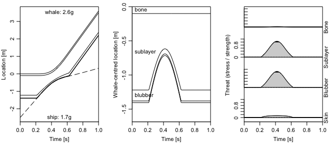

```r
library(whalestrike)
t <- seq(0, 1, length.out=200)
state <- list(xs=-2.5, vs=10*knot2SI, xw=0, vw=0) # 10 knot ship
parms <- parameters() # defaults
sol <- strike(t, state, parms)
par(mfcol=c(1, 3), mar=c(3.3, 3, 1, 2), mgp=c(2, 0.7, 0), cex=0.7)
plot(sol)
```

**Exercises.** Rerun the simulation with different parameters, e.g. (1) lower the speed until the blubber threat level decrease to below 1.0, (2) vary whale length to consider the effects of strikes on immature animals, and (3) model strikes near the mandible, by altering the thickness, modulus, and strength of the sublayer. (See the documentation for parameters to learn how to set the relevant parameters of the ship and whale, and use that for strike to learn about setting vessel speed and the simulation time interval.)

## 3.2 Threat dependence on impact area

This example shows how to extract information from a sequence of simulations, to create a graphical display that is not part of the default list. For clarity, this is done with a loop rather than using e.g `lapply`.

```r
library(whalestrike)
t <- seq(0, 1, length.out=200)
state <- list(xs=-1.5, vs=10*knot2SI, xw=0, vw=0) # 10 knots
area <- seq(0.2, 2, length.out=100)
stress <- rep(NA, length.out=length(area)) # compressive stress [MPa]
for (i in seq_along(area)) {
    L <- sqrt(area[i])
    parms <- parameters(Ly=L, Lz=L)
    sol <- strike(t, state, parms)
    stress[i] <- max(sol$WCF$stress) / 1e6
}
```

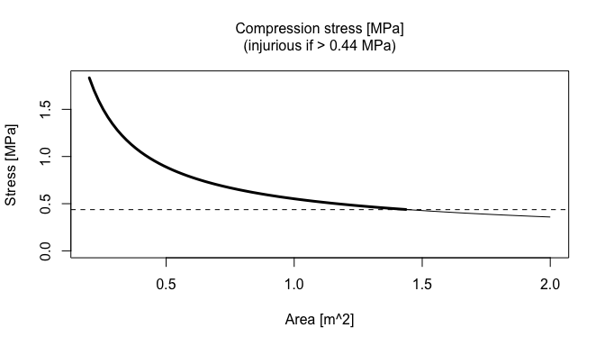

```r
danger <- parms$s[2] / 1e6
plot(area, stress, type="l", xlab="Area [m^2]", ylab="Stress [MPa]",
     ylim=c(0, max(stress)))
lines(area[stress>=danger], stress[stress>=danger], lwd=3)
abline(h=danger, lty="dashed")
mtext(sprintf("Compression stress [MPa]\n(injurious if > %.2f MPa)", danger),
      side=3, line=1)
```

**Exercise.** Look at the help for `plot.strike()`, to learn how to examine skin stress in the y and z directions separately, and then explore the effect of adjusting impact geometry, at constant area.

## 3.3 Threat dependence on blubber thickness and ship speed

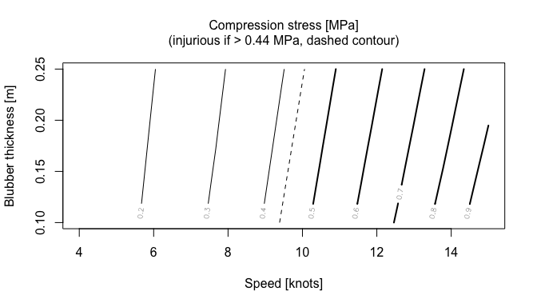

```r
library(whalestrike)
t <- seq(0, 1, length.out=200)
## Hint: the following creates x and y of different lengths,
## so that mismatches between row/col and i/j values will
## yield errors.
l2 <- seq(0.1, 0.25, length.out=9) # blubber thickness
speedK <- seq(4, 15, length.out=10) # in knots
speed <- knot2SI * speedK
## stress = peak stress during each simulation, in MPa
stress <- matrix(NA, nrow=length(speed), ncol=length(l2))
l <- parameters()$l
for (i in seq_along(l2)) {
    for (j in seq_along(speed)) {
        state <- list(xs=-1.5, vs=speed[j], xw=0, vw=0)
        parms <- parameters(l=c(l[1], l2[i], l[3], l[4]))
        sol <- strike(t, state, parms)
        stress[j, i] <- max(sol$WCF$stress) / 1e6
    }
}
danger <- parms$s[2] / 1e6
contour(speedK, l2, stress, levels=seq(0, danger, 0.1),
        xlab="Speed [knots]", ylab="Blubber thickness [m]")
contour(speedK, l2, stress, level=danger, lty=2, add=TRUE, drawlabels=FALSE)
contour(speedK, l2, stress, level=seq(3, danger, -0.1), lwd=2, add=TRUE)
mtext(sprintf("Compression stress [MPa]\n(injurious if > %.2f MPa, dashed contour)", danger),
      side=3, line=1)
```

**Exercise.** Explore the effect of varying sublayer properties and thickness on this graph.

# 4 Further reading

See whalestrike for some references to the literature, and individual help pages for details of the various functions in the package.